# EDA — Tabla de Clientes Mibanco (Reto 2)

**Fuente:** `01_Tabla_de_Clientes.xlsx` · **50,000 clientes · 20 variables**

Este notebook hace el análisis exploratorio completo con gráficas inline:

1. Calidad de datos
2. Hallazgo metodológico (correlaciones)
3. Panorama demográfico
4. Adopción digital
5. Canales de contacto
6. Riesgo y pago
7. Matriz estratégica accionable

> Ejecuta todas las celdas con **Run All**. Requiere: `pandas openpyxl matplotlib seaborn`.

```python
import os
import numpy as np
import pandas as pd
import matplotlib.pyplot as plt
import seaborn as sns

%matplotlib inline

# Paleta Mibanco
NARANJA, ROJO, AZUL, GRIS, VERDE = "#F47B20", "#E2231A", "#1B3A6B", "#6B7280", "#2E9E5B"
PAL = [NARANJA, AZUL, VERDE, ROJO, GRIS]
sns.set_theme(style="whitegrid", palette=PAL)
plt.rcParams.update({
    "figure.dpi": 110, "font.size": 10, "axes.titleweight": "bold",
    "axes.titlesize": 12, "figure.titleweight": "bold", "figure.titlesize": 15,
})

# Carga (ruta relativa al notebook)
PATH = "01_Tabla_de_Clientes.xlsx"
if not os.path.exists(PATH):
    PATH = os.path.join("reto2_insights", "01_Tabla_de_Clientes.xlsx")
df = pd.read_excel(PATH)
print(f"Cargados {len(df):,} clientes y {df.shape[1]} columnas")
df.head()
```

```
Cargados 50,000 clientes y 20 columnas
```

|  | cliente_id | edad | genero | region | zona | tipo_cliente | es_digital | uso_app | uso_whatsapp | interaccion_digital_score | canal_whatsapp | canal_sms | canal_llamada | canal_campo | score_riesgo | prob_default | num_atrasos_previos | dias_mora_promedio | ratio_pago | ultimo_pago_dias |
| --- | --- | --- | --- | --- | --- | --- | --- | --- | --- | --- | --- | --- | --- | --- | --- | --- | --- | --- | --- | --- |
| 0 | 1 | 59 | F | Lima | urbano | recurrente | 0 | 0.36 | 1 | 27 | 1 | 1 | 1 | 0 | 375 | 0.425 | 2 | 7 | 0.67 | 80 |
| 1 | 2 | 49 | F | Centro | urbano | nuevo | 0 | 0.68 | 1 | 67 | 1 | 1 | 1 | 1 | 605 | 0.252 | 2 | 50 | 0.26 | 52 |
| 2 | 3 | 35 | F | Norte | rural | recurrente | 1 | 0.09 | 1 | 56 | 1 | 1 | 1 | 0 | 767 | 0.055 | 3 | 21 | 0.59 | 81 |
| 3 | 4 | 63 | F | Sur | urbano | nuevo | 1 | 0.38 | 1 | 43 | 1 | 1 | 1 | 0 | 602 | 0.147 | 2 | 31 | 0.44 | 57 |
| 4 | 5 | 28 | M | Lima | urbano | nuevo | 1 | 0.87 | 1 | 93 | 1 | 1 | 1 | 0 | 737 | 0.870 | 2 | 19 | 0.15 | 21 |

## 1. Calidad de datos

Tipos, nulos y cardinalidad de cada variable.

```python
info = pd.DataFrame({
    "dtype": df.dtypes.astype(str),
    "nulos": df.isna().sum(),
    "pct_nulos": (df.isna().mean() * 100).round(1),
    "unicos": df.nunique(),
})
print("Duplicados de cliente_id:", df["cliente_id"].duplicated().sum())
info
```

```
Duplicados de cliente_id: 0
```

|  | dtype | nulos | pct_nulos | unicos |
| --- | --- | --- | --- | --- |
| cliente_id | int64 | 0 | 0.0 | 50000 |
| edad | int64 | 0 | 0.0 | 49 |
| genero | str | 0 | 0.0 | 2 |
| region | str | 0 | 0.0 | 4 |
| zona | str | 0 | 0.0 | 2 |
| tipo_cliente | str | 0 | 0.0 | 2 |
| es_digital | int64 | 0 | 0.0 | 2 |
| uso_app | float64 | 0 | 0.0 | 101 |
| uso_whatsapp | int64 | 0 | 0.0 | 2 |
| interaccion_digital_score | int64 | 0 | 0.0 | 101 |
| canal_whatsapp | int64 | 0 | 0.0 | 2 |
| canal_sms | int64 | 0 | 0.0 | 2 |
| canal_llamada | int64 | 0 | 0.0 | 1 |
| canal_campo | int64 | 0 | 0.0 | 2 |
| score_riesgo | int64 | 0 | 0.0 | 550 |
| prob_default | float64 | 0 | 0.0 | 1001 |
| num_atrasos_previos | int64 | 0 | 0.0 | 11 |
| dias_mora_promedio | int64 | 0 | 0.0 | 60 |
| ratio_pago | float64 | 0 | 0.0 | 101 |
| ultimo_pago_dias | int64 | 0 | 0.0 | 90 |

```python
df.describe().T.round(2)
```

|  | count | mean | std | min | 25% | 50% | 75% | max |
| --- | --- | --- | --- | --- | --- | --- | --- | --- |
| cliente_id | 50000.0 | 25000.50 | 14433.90 | 1.0 | 12500.75 | 25000.5 | 37500.25 | 50000.0 |
| edad | 50000.0 | 44.99 | 14.11 | 21.0 | 33.00 | 45.0 | 57.00 | 69.0 |
| es_digital | 50000.0 | 0.65 | 0.48 | 0.0 | 0.00 | 1.0 | 1.00 | 1.0 |
| uso_app | 50000.0 | 0.50 | 0.29 | 0.0 | 0.25 | 0.5 | 0.75 | 1.0 |
| uso_whatsapp | 50000.0 | 0.70 | 0.46 | 0.0 | 0.00 | 1.0 | 1.00 | 1.0 |
| interaccion_digital_score | 50000.0 | 49.73 | 29.22 | 0.0 | 24.00 | 49.0 | 75.00 | 100.0 |
| canal_whatsapp | 50000.0 | 0.79 | 0.41 | 0.0 | 1.00 | 1.0 | 1.00 | 1.0 |
| canal_sms | 50000.0 | 0.80 | 0.40 | 0.0 | 1.00 | 1.0 | 1.00 | 1.0 |
| canal_llamada | 50000.0 | 1.00 | 0.00 | 1.0 | 1.00 | 1.0 | 1.00 | 1.0 |
| canal_campo | 50000.0 | 0.40 | 0.49 | 0.0 | 0.00 | 0.0 | 1.00 | 1.0 |
| score_riesgo | 50000.0 | 574.39 | 158.71 | 300.0 | 437.00 | 575.0 | 711.00 | 849.0 |
| prob_default | 50000.0 | 0.50 | 0.29 | 0.0 | 0.25 | 0.5 | 0.75 | 1.0 |
| num_atrasos_previos | 50000.0 | 2.00 | 1.41 | 0.0 | 1.00 | 2.0 | 3.00 | 10.0 |
| dias_mora_promedio | 50000.0 | 29.46 | 17.29 | 0.0 | 14.00 | 30.0 | 44.00 | 59.0 |
| ratio_pago | 50000.0 | 0.50 | 0.29 | 0.0 | 0.25 | 0.5 | 0.75 | 1.0 |
| ultimo_pago_dias | 50000.0 | 44.44 | 26.00 | 0.0 | 22.00 | 45.0 | 67.00 | 89.0 |

## 2. Hallazgo metodológico — Matriz de correlación

**Lo más importante del análisis.** Casi todas las correlaciones son ≈ 0: las variables son estadísticamente independientes (dataset sintético). La única relación relevante es `uso_whatsapp ↔ canal_whatsapp = 0.79`. Implicancia: hoy no hay señal predictiva para un modelo; el valor está en la **segmentación** y el **framework de targeting**.

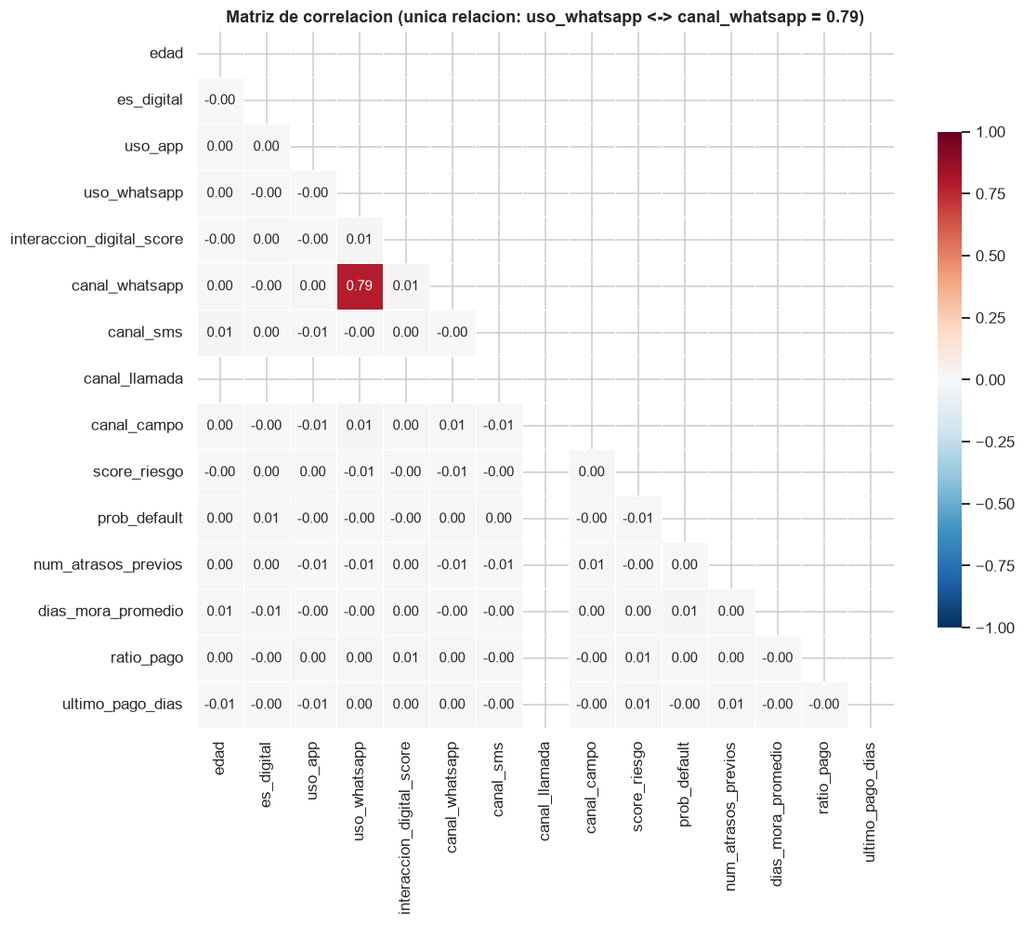

```python
num = df.select_dtypes("number").drop(columns=["cliente_id"], errors="ignore")
corr = num.corr()
fig, ax = plt.subplots(figsize=(11, 9))
mask = np.triu(np.ones_like(corr, dtype=bool))
sns.heatmap(corr, mask=mask, annot=True, fmt=".2f", cmap="RdBu_r", center=0,
            vmin=-1, vmax=1, square=True, linewidths=.5, cbar_kws={"shrink": .7}, ax=ax)
ax.set_title("Matriz de correlacion (unica relacion: uso_whatsapp <-> canal_whatsapp = 0.79)")
plt.show()
```

## 3. Panorama demográfico

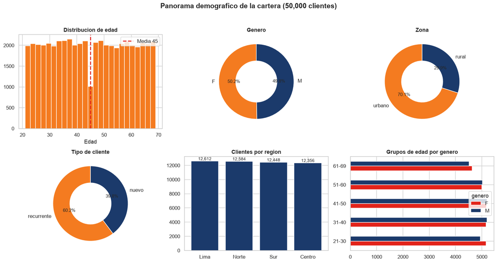

```python
fig, ax = plt.subplots(2, 3, figsize=(15, 8))
fig.suptitle("Panorama demografico de la cartera (50,000 clientes)")

ax[0, 0].hist(df["edad"], bins=25, color=NARANJA, edgecolor="white")
ax[0, 0].set_title("Distribucion de edad"); ax[0, 0].set_xlabel("Edad")
ax[0, 0].axvline(df["edad"].mean(), color=ROJO, ls="--", lw=2, label=f"Media {df['edad'].mean():.0f}")
ax[0, 0].legend()

for a, col, ttl in [(ax[0, 1], "genero", "Genero"), (ax[0, 2], "zona", "Zona"),
                    (ax[1, 0], "tipo_cliente", "Tipo de cliente")]:
    vc = df[col].value_counts()
    a.pie(vc, labels=vc.index, autopct="%1.1f%%", colors=PAL, startangle=90,
          wedgeprops=dict(width=0.45, edgecolor="white"))
    a.set_title(ttl)

vc = df["region"].value_counts()
ax[1, 1].bar(vc.index, vc.values, color=AZUL); ax[1, 1].set_title("Clientes por region")
for i, v in enumerate(vc.values):
    ax[1, 1].text(i, v, f"{v:,}", ha="center", va="bottom", fontsize=9)

bins, labels = [20, 30, 40, 50, 60, 70], ["21-30", "31-40", "41-50", "51-60", "61-69"]
df["grupo_edad"] = pd.cut(df["edad"], bins=bins, labels=labels, include_lowest=True)
ct = df.groupby(["grupo_edad", "genero"], observed=True).size().unstack()
ct.plot(kind="barh", ax=ax[1, 2], color=[ROJO, AZUL])
ax[1, 2].set_title("Grupos de edad por genero"); ax[1, 2].set_ylabel("")
fig.tight_layout(rect=[0, 0, 1, 0.95]); plt.show()
```

## 4. Adopción digital

64.8% son clientes digitales; ~35% (≈17,600) NO lo son → bolsa de migración.

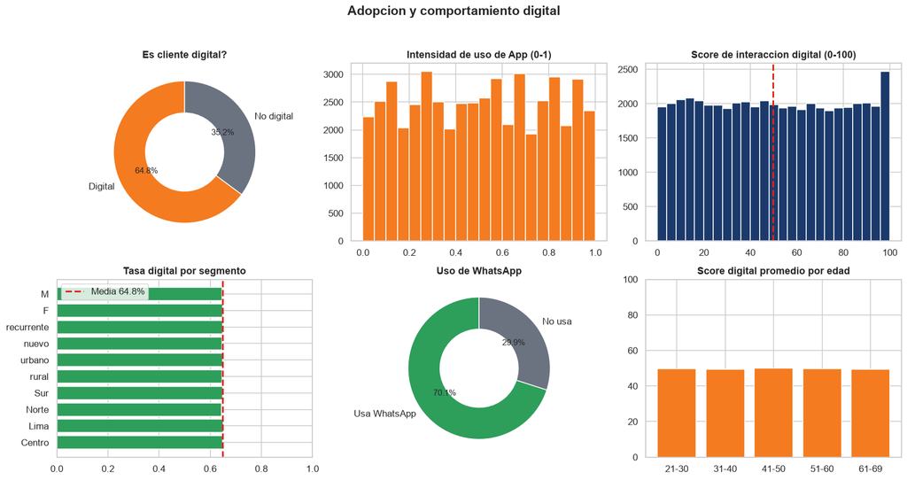

```python
fig, ax = plt.subplots(2, 3, figsize=(15, 8))
fig.suptitle("Adopcion y comportamiento digital")

dig = df["es_digital"].mean()
ax[0, 0].pie([dig, 1 - dig], labels=["Digital", "No digital"], autopct="%1.1f%%",
             colors=[NARANJA, GRIS], startangle=90, wedgeprops=dict(width=0.45, edgecolor="white"))
ax[0, 0].set_title("Es cliente digital?")
ax[0, 1].hist(df["uso_app"], bins=20, color=NARANJA, edgecolor="white")
ax[0, 1].set_title("Intensidad de uso de App (0-1)")
ax[0, 2].hist(df["interaccion_digital_score"], bins=25, color=AZUL, edgecolor="white")
ax[0, 2].set_title("Score de interaccion digital (0-100)")
ax[0, 2].axvline(df["interaccion_digital_score"].mean(), color=ROJO, ls="--", lw=2)

adopt = {}
for c in ["region", "zona", "tipo_cliente", "genero"]:
    for k, v in df.groupby(c)["es_digital"].mean().items():
        adopt[str(k)] = v
s = pd.Series(adopt)
ax[1, 0].barh(s.index, s.values, color=VERDE)
ax[1, 0].axvline(dig, color=ROJO, ls="--", lw=2, label=f"Media {dig:.1%}")
ax[1, 0].set_xlim(0, 1); ax[1, 0].set_title("Tasa digital por segmento"); ax[1, 0].legend()

wa = df["uso_whatsapp"].mean()
ax[1, 1].pie([wa, 1 - wa], labels=["Usa WhatsApp", "No usa"], autopct="%1.1f%%",
             colors=[VERDE, GRIS], startangle=90, wedgeprops=dict(width=0.45, edgecolor="white"))
ax[1, 1].set_title("Uso de WhatsApp")

ge = df.groupby("grupo_edad", observed=True)["interaccion_digital_score"].mean()
ax[1, 2].bar(ge.index.astype(str), ge.values, color=NARANJA)
ax[1, 2].set_title("Score digital promedio por edad"); ax[1, 2].set_ylim(0, 100)
fig.tight_layout(rect=[0, 0, 1, 0.95]); plt.show()
```

## 5. Canales de contacto

Llamada 100% · SMS 80% · WhatsApp 79% · Campo 40% (el más caro).

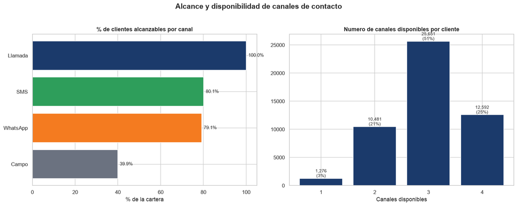

```python
fig, ax = plt.subplots(1, 2, figsize=(15, 6))
fig.suptitle("Alcance y disponibilidad de canales de contacto")

canales = {"Llamada": df["canal_llamada"].mean(), "SMS": df["canal_sms"].mean(),
           "WhatsApp": df["canal_whatsapp"].mean(), "Campo": df["canal_campo"].mean()}
s = pd.Series(canales).sort_values()
ax[0].barh(s.index, s.values * 100, color=[GRIS, NARANJA, VERDE, AZUL])
ax[0].set_title("% de clientes alcanzables por canal"); ax[0].set_xlabel("% de la cartera"); ax[0].set_xlim(0, 105)
for i, v in enumerate(s.values):
    ax[0].text(v * 100 + 1, i, f"{v:.1%}", va="center", fontsize=10)

df["n_canales"] = df[["canal_whatsapp", "canal_sms", "canal_llamada", "canal_campo"]].sum(axis=1)
nc = df["n_canales"].value_counts().sort_index()
ax[1].bar(nc.index.astype(str), nc.values, color=AZUL)
ax[1].set_title("Numero de canales disponibles por cliente"); ax[1].set_xlabel("Canales disponibles")
for i, (idx, v) in enumerate(nc.items()):
    ax[1].text(i, v, f"{v:,}\n({v/len(df):.0%})", ha="center", va="bottom", fontsize=9)
fig.tight_layout(rect=[0, 0, 1, 0.95]); plt.show()
```

## 6. Riesgo y comportamiento de pago

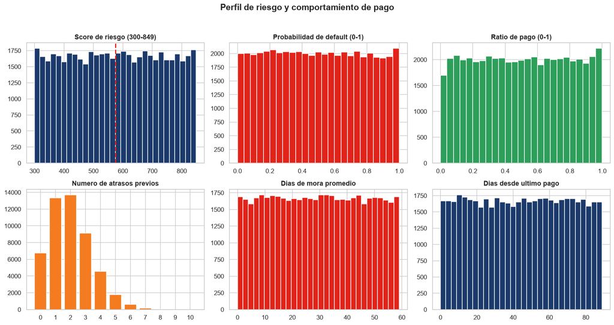

```python
fig, ax = plt.subplots(2, 3, figsize=(15, 8))
fig.suptitle("Perfil de riesgo y comportamiento de pago")
ax[0, 0].hist(df["score_riesgo"], bins=30, color=AZUL, edgecolor="white")
ax[0, 0].set_title("Score de riesgo (300-849)")
ax[0, 0].axvline(df["score_riesgo"].mean(), color=ROJO, ls="--", lw=2)
ax[0, 1].hist(df["prob_default"], bins=25, color=ROJO, edgecolor="white"); ax[0, 1].set_title("Probabilidad de default (0-1)")
ax[0, 2].hist(df["ratio_pago"], bins=25, color=VERDE, edgecolor="white"); ax[0, 2].set_title("Ratio de pago (0-1)")
vc = df["num_atrasos_previos"].value_counts().sort_index()
ax[1, 0].bar(vc.index.astype(str), vc.values, color=NARANJA); ax[1, 0].set_title("Numero de atrasos previos")
ax[1, 1].hist(df["dias_mora_promedio"], bins=30, color=ROJO, edgecolor="white"); ax[1, 1].set_title("Dias de mora promedio")
ax[1, 2].hist(df["ultimo_pago_dias"], bins=30, color=AZUL, edgecolor="white"); ax[1, 2].set_title("Dias desde ultimo pago")
fig.tight_layout(rect=[0, 0, 1, 0.95]); plt.show()
```

## 7. Matriz estratégica accionable

Cruce **madurez digital** (score ≥ 50) × **riesgo** (prob. default ≥ 0.5). Cada cuadrante tiene una acción recomendada distinta.

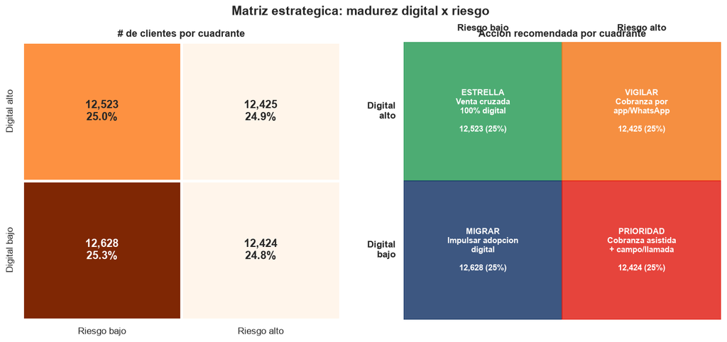

```python
df["riesgo_nivel"] = np.where(df["prob_default"] >= 0.5, "Riesgo alto", "Riesgo bajo")
df["digital_nivel"] = np.where(df["interaccion_digital_score"] >= 50, "Digital alto", "Digital bajo")
mat = pd.crosstab(df["digital_nivel"], df["riesgo_nivel"]).reindex(
    index=["Digital alto", "Digital bajo"], columns=["Riesgo bajo", "Riesgo alto"])
N = len(df)

fig, ax = plt.subplots(1, 2, figsize=(15, 6))
fig.suptitle("Matriz estrategica: madurez digital x riesgo")
sns.heatmap(mat, annot=mat.map(lambda v: f"{v:,}\n{v/N:.1%}"), fmt="", cmap="Oranges",
            linewidths=2, linecolor="white", cbar=False, ax=ax[0], annot_kws={"size": 13, "weight": "bold"})
ax[0].set_title("# de clientes por cuadrante"); ax[0].set_xlabel(""); ax[0].set_ylabel("")

quad = {("Digital alto", "Riesgo bajo"): "ESTRELLA\nVenta cruzada\n100% digital",
        ("Digital alto", "Riesgo alto"): "VIGILAR\nCobranza por\napp/WhatsApp",
        ("Digital bajo", "Riesgo bajo"): "MIGRAR\nImpulsar adopcion\ndigital",
        ("Digital bajo", "Riesgo alto"): "PRIORIDAD\nCobranza asistida\n+ campo/llamada"}
ax[1].axis("off"); ax[1].set_title("Accion recomendada por cuadrante")
colors_q = [[VERDE, NARANJA], [AZUL, ROJO]]
for i, dn in enumerate(["Digital alto", "Digital bajo"]):
    for j, rn in enumerate(["Riesgo bajo", "Riesgo alto"]):
        n_q = mat.loc[dn, rn]
        ax[1].add_patch(plt.Rectangle((j, 1 - i), 1, 1, color=colors_q[i][j], alpha=.85))
        ax[1].text(j + .5, 1 - i + .5, f"{quad[(dn, rn)]}\n\n{n_q:,} ({n_q/N:.0%})",
                   ha="center", va="center", color="white", fontsize=10, weight="bold")
ax[1].set_xlim(0, 2); ax[1].set_ylim(0, 2)
ax[1].text(0.5, 2.08, "Riesgo bajo", ha="center", fontsize=11, weight="bold")
ax[1].text(1.5, 2.08, "Riesgo alto", ha="center", fontsize=11, weight="bold")
ax[1].text(-0.05, 1.5, "Digital\nalto", ha="right", va="center", fontsize=11, weight="bold")
ax[1].text(-0.05, 0.5, "Digital\nbajo", ha="right", va="center", fontsize=11, weight="bold")
plt.show()
```

```python
# Tabla resumen por segmento
df.groupby(["digital_nivel", "riesgo_nivel"], observed=True).agg(
    clientes=("cliente_id", "count"),
    edad_prom=("edad", "mean"),
    prob_default_prom=("prob_default", "mean"),
    score_digital_prom=("interaccion_digital_score", "mean"),
    pct_whatsapp=("canal_whatsapp", "mean"),
).round(2)
```

| digital_nivel | riesgo_nivel | clientes | edad_prom | prob_default_prom | score_digital_prom | pct_whatsapp |
| --- | --- | --- | --- | --- | --- | --- |
| Digital alto | Riesgo alto | 12425 | 44.98 | 0.75 | 75.17 | 0.80 |
|  | Riesgo bajo | 12523 | 44.92 | 0.25 | 75.02 | 0.79 |
| Digital bajo | Riesgo alto | 12424 | 45.10 | 0.75 | 24.24 | 0.79 |
|  | Riesgo bajo | 12628 | 44.96 | 0.25 | 24.70 | 0.79 |

## Resumen ejecutivo — conclusiones clave

1. **Datos limpios pero sintéticos:** 0 nulos/duplicados, pero variables independientes (correlaciones ≈ 0). Sin señal predictiva hoy → el valor está en segmentación y framework, no en un modelo entrenado sobre estos datos.
2. **Cartera:** 70% urbano, 60% recurrente, edad media 45, género balanceado.
3. **Digital:** 64.8% digital, 70% usa WhatsApp; **~17,600 no digitales** = oportunidad de migración.
4. **Canales:** Llamada 100% · SMS 80% · WhatsApp 79% · Campo 40% (el más caro) → mover gestiones de campo a digital reduce costo.
5. **Acción:** 4 cuadrantes (Estrella / Vigilar / Migrar / Prioridad) con estrategia diferenciada de venta, cobranza y adopción.

**Próximo paso:** confirmar si existe versión con datos reales/etiquetas para entrenar scoring de adopción y de riesgo.